# Hockey Prediction

Author: Louis-Pierre Gagnaux  
Public Git Repo: https://github.com/gagnauxl/hockey_prediction  
Daten Swiss National League: https://www.sihf.ch/de/game-center/national-league/#/standing/rank/asc/page/0/

```python
import data_service as dp
from team import Team
import ranking_regression as rr
import lin_regression as lr
import knn_regression as knn
import elo_regression as elo
import rpart_regression as rp
import random_forest as rf
```

```python
data = dp.load_data()
data_proj=data[['Datum', 'Home', 'Away', 'Resultat']].tail(5)
print(f"Last 5 games:\n{data_proj.to_string()}")
```

```
Last 5 games:
          Datum                       Home             Away Resultat
359  09/03/2026         Genève-Servette HC       EHC Kloten    07:00
360  09/03/2026                  HC Lugano           EV Zug    04:01
361  09/03/2026                Lausanne HC         HC Ajoie    02:03
362  09/03/2026  SC Rapperswil-Jona Lakers  HC Ambri-Piotta    06:02
363  09/03/2026                 SCL Tigers        ZSC Lions    00:02
```

```python
X, y, df = dp.load()         # Lädt die Daten, bereitet sie vor und teilt sie in Features (X) und Zielvariable (y) auf
print(f"Last 10 values of df: \n{df[['Home_Id', 'Away_Id', 'Home', 'Away', 'Resultat', 'OT/SO', 'Points']].head(10).to_string()}")
print(f"Features: {X.shape}")
#X.info()
print(X.head())
print(f"\nShape of target variable y: {y.shape}\n{y[:5]}")
```

```
Last 10 values of df:
   Home_Id  Away_Id                       Home                Away Resultat OT/SO  Points
0        0       10            HC Ambri-Piotta          EHC Kloten    02:01   NaN       3
1        1       12                   HC Davos         Lausanne HC    04:01   NaN       3
2        2       11          Fribourg-Gottéron           HC Lugano    03:02    OT       2
3        3        8         Genève-Servette HC            HC Ajoie    05:03   NaN       3
4        4       13  SC Rapperswil-Jona Lakers          SCL Tigers    05:01   NaN       3
5        5        7                  ZSC Lions     EHC Biel-Bienne    04:03   NaN       3
6        6        9                     EV Zug             SC Bern    03:00   NaN       3
7        7        1            EHC Biel-Bienne            HC Davos    01:04   NaN       0
8        8        5                   HC Ajoie           ZSC Lions    00:04   NaN       0
9        9        3                    SC Bern  Genève-Servette HC    02:01    SO       2
Features: (364, 2)
   Home_Id  Away_Id
0        0       10
1        1       12
2        2       11
3        3        8
4        4       13

Shape of target variable y: (364,)
0    3
1    3
2    2
3    3
4    3
Name: Points, dtype: int64
```

## 1. Linear Regression

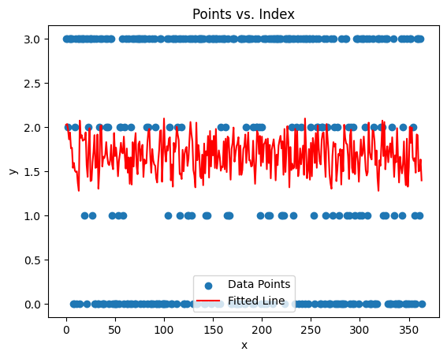

```python
model=lr.fit(X, y)
dp.plot_results(df, model)
```

```
Number of training items: 280, test items: 84
Training on rounds 0 to 40, testing on rounds 40 to 52
                                 OLS Regression Results
=======================================================================================
Dep. Variable:                 Points   R-squared (uncentered):                   0.521
Model:                            OLS   Adj. R-squared (uncentered):              0.518
Method:                 Least Squares   F-statistic:                              196.8
Date:                Sun, 19 Apr 2026   Prob (F-statistic):                    1.41e-58
Time:                        18:06:48   Log-Likelihood:                         -660.47
No. Observations:                 364   AIC:                                      1325.
Df Residuals:                     362   BIC:                                      1333.
Df Model:                           2
Covariance Type:            nonrobust
==============================================================================
                 coef    std err          t      P>|t|      [0.025      0.975]
------------------------------------------------------------------------------
Home_Id        0.0775      0.014      5.418      0.000       0.049       0.106
Away_Id        0.1405      0.014      9.818      0.000       0.112       0.169
==============================================================================
Omnibus:                      203.202   Durbin-Watson:                   1.837
Prob(Omnibus):                  0.000   Jarque-Bera (JB):               23.812
Skew:                          -0.191   Prob(JB):                     6.75e-06
Kurtosis:                       1.807   Cond. No.                         2.38
==============================================================================

Notes:
[1] R² is computed without centering (uncentered) since the model does not contain a constant.
[2] Standard Errors assume that the covariance matrix of the errors is correctly specified.
```

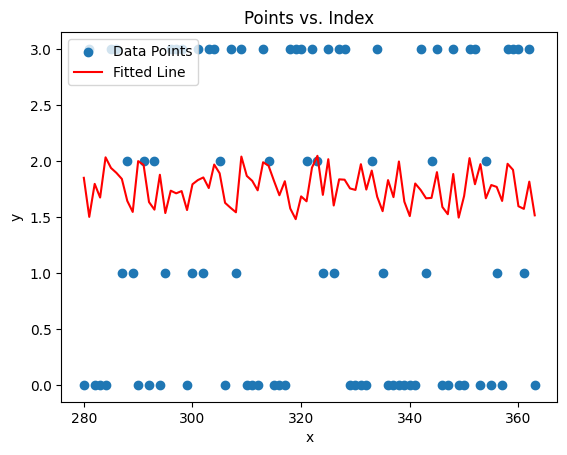

```
Predicted values y_hut) are rounded:
Model RMSE: 2.0557700445795186
Model R^2: -1.4581650317368715
Model Accuracy: 0.34523809523809523
```

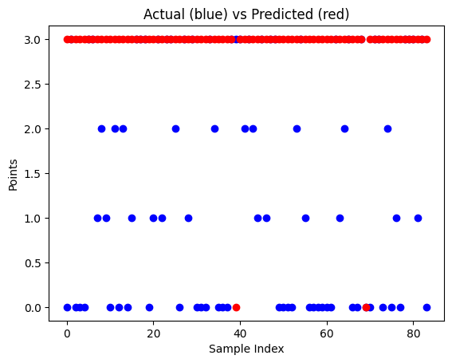

```python
# train 40 Runden, test letzte 12 Runden
lr.analyze_model_performance(df=df, X=X, y=y, train_idx_start=0, train_idx_end=40, test_idx_start=40, test_idx_end=52)
```

Die vorausgesagten Punkte für sind letzten 12 Runden (84 Spiele) sind rot dargestellt und überschreiben die tatsächlichen Werte (blau). Je mehr man blaue Punkte sieht, desto schlechter ist das Modell. Die Accuracy von 0.35 ist entsprechend schlecht. Raten wäre vermutlich besser.

Aber: Die letzten Runden vor den Playoffs werden ganz anders gespielt und sind oft sehr unvorhersehbar sind, weil Teams, die schon qualifiziert sind, nicht mehr so motiviert sind, und Teams, die sich noch qualifizieren müssen, alles geben. Deshalb ist es vermutlich **falsch auf die ersten Runden zu trainieren und den letzten Runden zu testen.**

```
Number of training items: 70, test items: 70
Training on rounds 0 to 10, testing on rounds 10 to 20
                                 OLS Regression Results
=======================================================================================
Dep. Variable:                 Points   R-squared (uncentered):                   0.521
Model:                            OLS   Adj. R-squared (uncentered):              0.518
Method:                 Least Squares   F-statistic:                              196.8
Date:                Sun, 19 Apr 2026   Prob (F-statistic):                    1.41e-58
Time:                        18:06:48   Log-Likelihood:                         -660.47
No. Observations:                 364   AIC:                                      1325.
Df Residuals:                     362   BIC:                                      1333.
Df Model:                           2
Covariance Type:            nonrobust
==============================================================================
                 coef    std err          t      P>|t|      [0.025      0.975]
------------------------------------------------------------------------------
Home_Id        0.0775      0.014      5.418      0.000       0.049       0.106
Away_Id        0.1405      0.014      9.818      0.000       0.112       0.169
==============================================================================
Omnibus:                      203.202   Durbin-Watson:                   1.837
Prob(Omnibus):                  0.000   Jarque-Bera (JB):               23.812
Skew:                          -0.191   Prob(JB):                     6.75e-06
Kurtosis:                       1.807   Cond. No.                         2.38
==============================================================================

Notes:
[1] R² is computed without centering (uncentered) since the model does not contain a constant.
[2] Standard Errors assume that the covariance matrix of the errors is correctly specified.
```

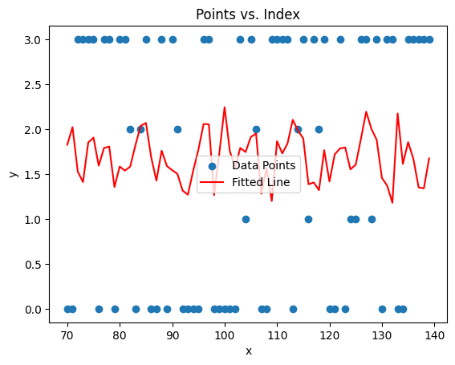

```
Predicted values y_hut) are rounded:
Model RMSE: 1.8935982376719422
Model R^2: -0.8763348996155484
Model Accuracy: 0.4857142857142857
```

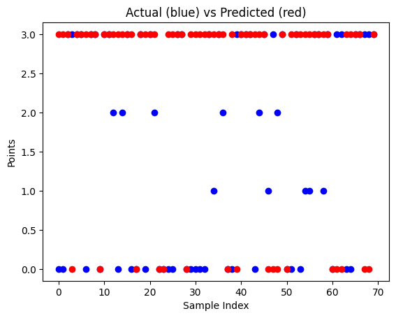

```python
# train 10 Runden, test nächste 10 Runde
lr.analyze_model_performance(df=df, X=X, y=y, train_idx_start=0, train_idx_end=10, test_idx_start=10, test_idx_end=20)
```

Was sich bestätigt, wenn auf die ersten 10 Runden trainiert und den nächsten 10 Runden testet, ist die Accuracy (0.49) besser.

# 2. Vorausage nach Ranking

Vorhersage der Punkte basierend auf der Rangliste der Teams, die aus den vorherigen Spielen erstellt wird. Diese Taktik sollte man schlagen können.

```
Number of training items: 70, test items: 70
Training on rounds 0 to 10, testing on rounds 10 to 20
                         Team  Punkte  Spiele
0                 Lausanne HC      27      11
1                    HC Davos      26      10
2           Fribourg-Gottéron      21      10
3          Genève-Servette HC      20      10
4   SC Rapperswil-Jona Lakers      20      10
5                   ZSC Lions      17      10
6                      EV Zug      17      10
7                  EHC Kloten      12      11
8                  SCL Tigers      11      10
9             EHC Biel-Bienne      11       9
10                  HC Lugano       8      10
11                    SC Bern       8       9
12            HC Ambri-Piotta       7      10
13                   HC Ajoie       5      10
Model RMSE: 1.886038933093073
Model R^2: -0.8613840239214008
Model Accuracy: 0.4714285714285714
```

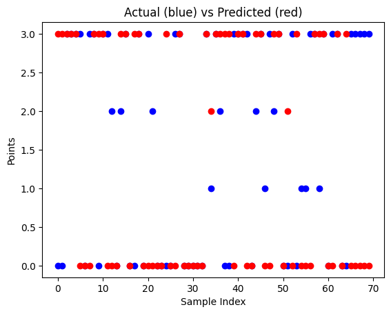

```python
rr.analyze_model_performance(df=df, X=X, y=y, train_idx_start=0, train_idx_end=10, test_idx_start=10, test_idx_end=20)
```

Accuracy ist ca. 0.47, vergleichbar mit linearer Regression

# 3. KNN: k-Nearest-Neighbor-Algorithmus

Auch mit KNN, und dem Trainieren auf den ersten 10 Runden und dem Testen auf den auf den folgenden 10 Runden, erhalten wir eine ähnlich Accuracy.

```
Number of training items: 70, test items: 70
Training on rounds 0 to 10, testing on rounds 10 to 20
Model RMSE: 1.9309509130403675
Model R^2: -0.9510892780862874
Model Accuracy: 0.42857142857142855
```

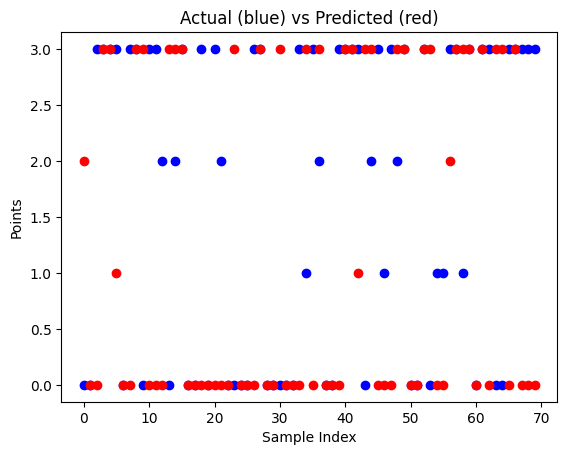

```python
knn.analyze_model_performance(df=df, X=X, y=y, train_idx_start=0, train_idx_end=10, test_idx_start=10, test_idx_end=20)
```

## 3.1 Ein Beispiel für Overfitting

Trainiert man alle Spiele, erhält man ein viel bessere Accuracy. Deshalb ist so wichtig Train-Set und Test-Set unterschiedlich zu halten um eine richtige Crossvalidierung zu erhalten.

```
Number of training items: 364, test items: 70
Training on rounds 0 to 52, testing on rounds 42 to 52
Model RMSE: 1.3522468075656264
Model R^2: -0.03751736915238557
Model Accuracy: 0.6571428571428571
```

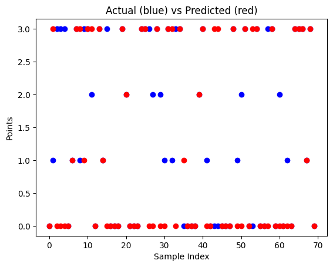

```python
knn.analyze_model_performance(df=df, X=X, y=y, train_idx_start=0, train_idx_end=52, test_idx_start=42, test_idx_end=52)
```

# 4. ELO-Rating

ELO Rating kommt eigentlich vom Schach und dient dazu die Spielstärke eines Spielers zu bestimmen, ohne dass alle Spieler gegeneinander gespielt haben müssen. Das kann man auch für Teams anwenden, indem man z.B. die letzten 5 Spiele anschaut und die Rangliste der letzten 5 Spiele bestimmt. Mit Elo ist das aussagekräftiger als nur eine Rangliste von Punkten, weil das Gewinnen gegen einen schwachen weniger während gegen einen starken Gegner mehr ELO-Punkte gibt und so eine bessere Aussage liefert.

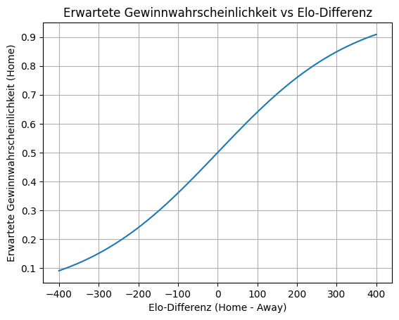

```python
elo.plot_expected_score()
```

Je nach Elo Differenz berechnet man die Wahrscheinlichkeit zu gewinnen, damit man danach Elo-Punkte berechnen kann, die im Fall eines Sieges dazukommen.

```
score: [0.         0.11111111 0.22222222 0.33333333 0.44444444 0.55555556
 0.66666667 0.77777778 0.88888889 1.        ]
score: [0.         0.11111111 0.22222222 0.33333333 0.44444444 0.55555556
 0.66666667 0.77777778 0.88888889 1.        ], new_home: [15.0, 13.333333333333332, 11.666666666666666, 10.000000000000002, 8.333333333333334, 6.666666666666666, 5.000000000000001, 3.333333333333335, 1.6666666666666674, 0.0]
```

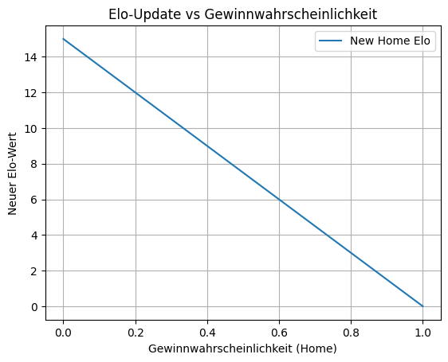

```python
elo.plot_update_elo()
```

Damit gewinnt ein Team 15 Punkte falls es kein Chance hat zu gewinnen und 0 falls es immer gewinnt. K = 15 ist damit ein Hyperparameter.

```
Number of training items: 294, test items: 70
Training on rounds 0 to 42, testing on rounds 42 to 52
Model RMSE: 1.535298947157477
Model R^2: -0.3374247336729972
Model Accuracy: 0.44285714285714284
```

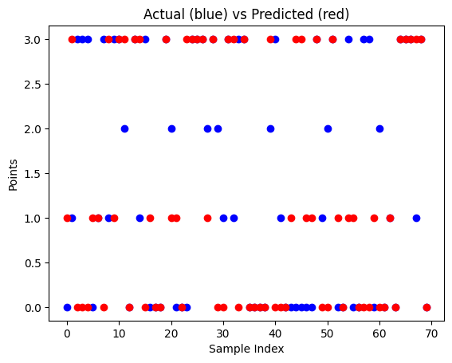

```python
elo.analyze_model_performance(df=df, X=X, y=y, train_idx_start=0, train_idx_end=42, test_idx_start=42, test_idx_end=52)
```

Auch mit Elo erhalten wir eine ähnliche Accuray wie mit Voraussage nach Rangliste. Und hier der Elo-Verlauf vom HC Davos und Ajoie zur Veranschaulichung.

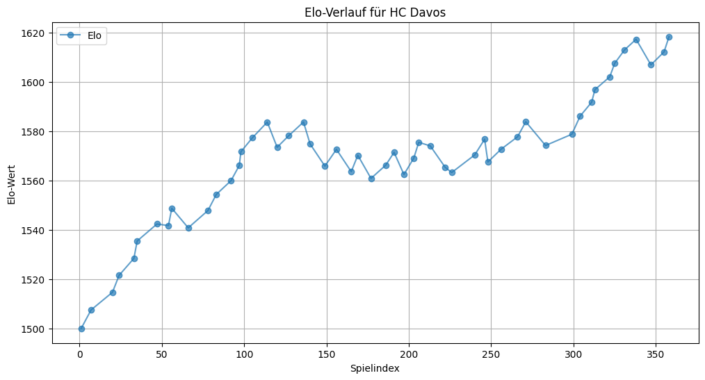

```
Final Elo for HC Davos: 1618.5
```

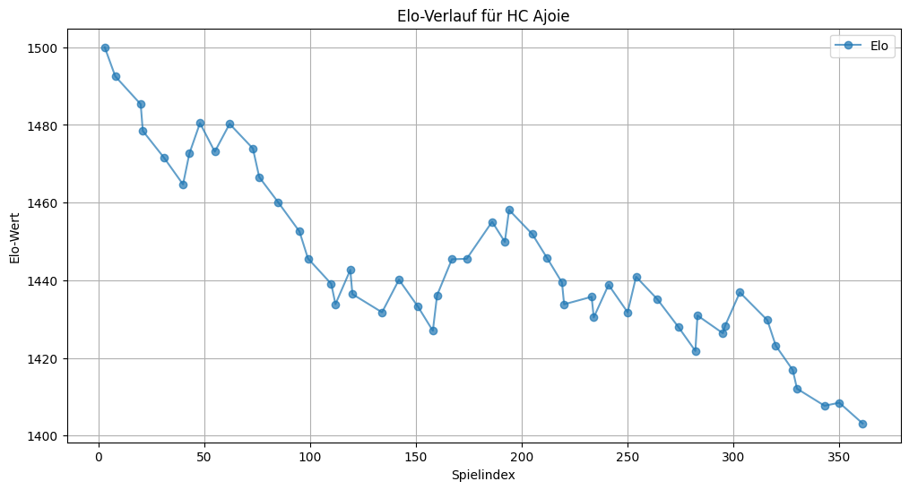

```
Final Elo for HC Ajoie: 1403.1
```

```python
elo.plot_Elo_HC_Davos_Ajoie(df)
```

# 5. Mit Goalie Statistik

https://www.sihf.ch/de/game-center/national-league/#/goalkeepers/goalsAgainstAverage/asc/page/0/2026/4940 --> alle Spiele  
https://www.sihf.ch/de/game-center/game/#/20261105000001 -> ein Spiel  
Seite laden, danach auf Player Stats --> Goalie Stat SVS%  
Hier kann man pro Spiel die Goalie Statistik herausholen

Mit nur dem Spielresultat lässt sich praktisch keine gute Voraussage machen, ca. 45% Treffer (Accuracy). Nimmt man aber andere Features die das Spiel beeinflussen wie die Goalie-fitness. Kann man die Voraussage deutlich verbessern, sofern man dann die Form des Torwarts in Vorraus weiss. Am besten man verwendet die Torstatistik SVS% (Anzahl gehaltener Schüsse im Verhältniss zu Anzahl Schüsse aufs Tor.

## 5.1 Lineare Regression

```python
X, y, df = dp.load(SVS=True)
print(f"Features: {X.shape}")
X.info()
```

```
Features: (364, 4)
<class 'pandas.core.frame.DataFrame'>
RangeIndex: 364 entries, 0 to 363
Data columns (total 4 columns):
 #   Column    Non-Null Count  Dtype
---  ------    --------------  -----
 0   Home_Id   364 non-null    int64
 1   Away_Id   364 non-null    int64
 2   SVS_Home  364 non-null    float64
 3   SVS_Away  364 non-null    float64
dtypes: float64(2), int64(2)
memory usage: 11.5 KB
```

```
Number of training items: 70, test items: 70
Training on rounds 0 to 10, testing on rounds 10 to 20
                                 OLS Regression Results
=======================================================================================
Dep. Variable:                 Points   R-squared (uncentered):                   0.715
Model:                            OLS   Adj. R-squared (uncentered):              0.712
Method:                 Least Squares   F-statistic:                              226.1
Date:                Sun, 19 Apr 2026   Prob (F-statistic):                    7.93e-97
Time:                        18:06:49   Log-Likelihood:                         -565.75
No. Observations:                 364   AIC:                                      1140.
Df Residuals:                     360   BIC:                                      1155.
Df Model:                           4
Covariance Type:            nonrobust
==============================================================================
                 coef    std err          t      P>|t|      [0.025      0.975]
------------------------------------------------------------------------------
Home_Id       -0.0360      0.015     -2.399      0.017      -0.066      -0.006
Away_Id        0.0218      0.015      1.451      0.148      -0.008       0.051
SVS_Home       0.1108      0.009     11.690      0.000       0.092       0.129
SVS_Away      -0.0908      0.009     -9.607      0.000      -0.109      -0.072
==============================================================================
Omnibus:                     1188.046   Durbin-Watson:                   1.804
Prob(Omnibus):                  0.000   Jarque-Bera (JB):               29.586
Skew:                          -0.137   Prob(JB):                     3.76e-07
Kurtosis:                       1.631   Cond. No.                         33.3
==============================================================================

Notes:
[1] R² is computed without centering (uncentered) since the model does not contain a constant.
[2] Standard Errors assume that the covariance matrix of the errors is correctly specified.
```

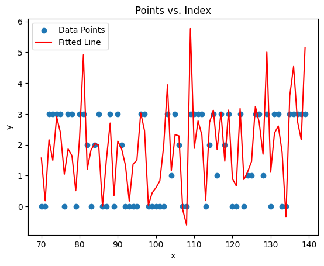

```
Predicted values y_hut) are rounded:
Model RMSE: 1.1084094137869043
Model R^2: 0.3571123451516447
Model Accuracy: 0.7428571428571429
```

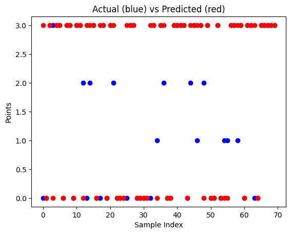

```python
lr.analyze_model_performance(df=df, X=X, y=y, train_idx_start=0, train_idx_end=10, test_idx_start=10, test_idx_end=20, SVS=True)
```

Bemerkenswert, ist das die SVS% sehr signifikanten Einfluss (p-value < 0.0.5) hat, während die Away-Id eigentlich keinen signifikanten Einfluss hat. Die Acurracy von 74% ist natürlich traumhaft, wenn man die Fitness des Torwarts voraussagen kann. In dieser Genauigkeit wie aus den Testdaten entnommen wurde, die tatsächlichen Ergebnisswerte, wird man das nie können. Deshalb ist das eigentlich nur eine Aussage, die jedermann im EIshockey schon kennt, dass der Torhüter mehr als 50% ausmacht.

## 5.2 Entscheidungsbaum

```
Number of training items: 70, test items: 70
Training on rounds 0 to 10, testing on rounds 10 to 20
Model RMSE: 0.9486832980505138
Model R^2: 0.5290474156343443
Model Accuracy: 0.7
```

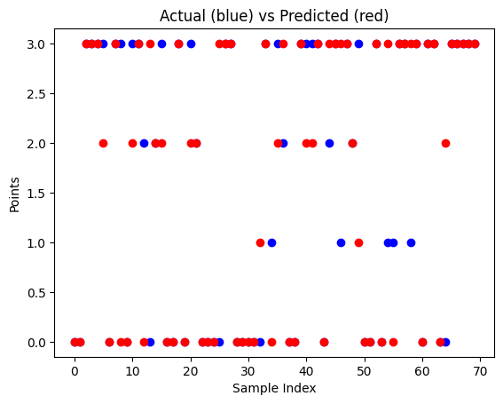

```
Decision Tree
```

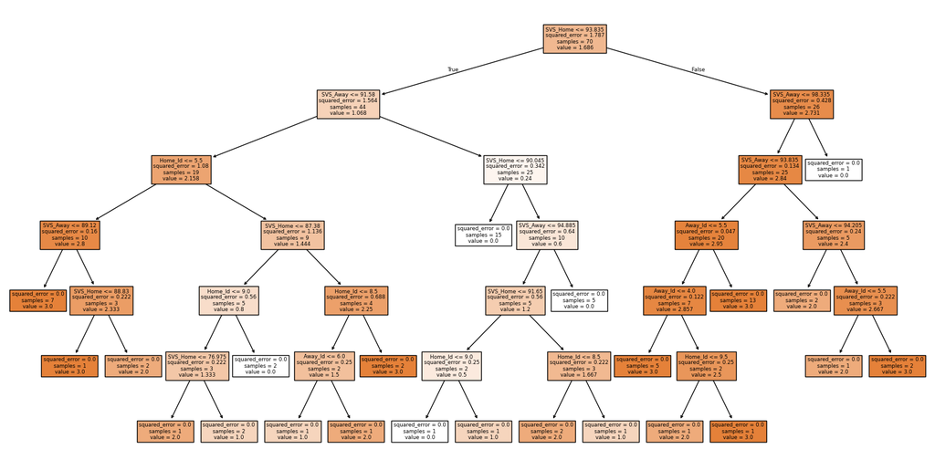

```python
rp.analyze_model_performance(df=df, X=X, y=y, train_idx_start=0, train_idx_end=10, test_idx_start=10, test_idx_end=20)
```

## 5.3 Random Forest Classifier

```
Number of training items: 70, test items: 70
Training on rounds 0 to 10, testing on rounds 10 to 20
y_hut: [0 0 3 3 3 3 0 3 0 0]
Model RMSE: 0.8944271909999159
Model R^2: 0.5813754805638617
Model Accuracy: 0.7571428571428571
```

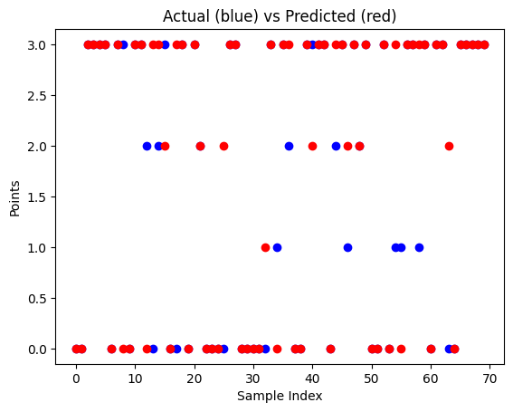

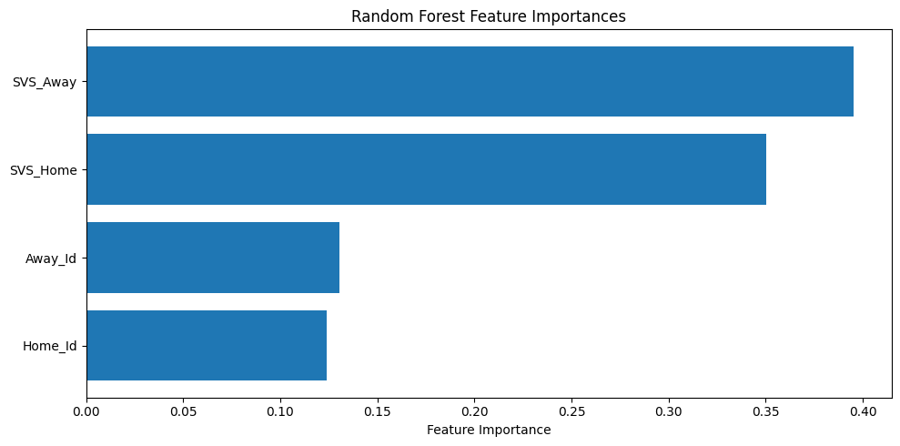

```python
rf.analyze_model_performance(df=df, X=X, y=y, train_idx_start=0, train_idx_end=10, test_idx_start=10, test_idx_end=20)
```

# 6. Zusammenfassung

Zusammenfassend ist Eishockey eine sehr volatile Sportart. Aus den Resultaten alleine lässt sich kaum eine verlässliche Voraussage machen. Weiss man mehr über die Spieler, ist der Topscorer verletzt oder der Torhüter angeschlagen, lässt sich die Voraussage deutchlich verbessern. Aber wie weiss man das.